# Inflación en tiempos de pandemia

Diciembre de 2021

## Introducción

> Record eurozone inflation of 4.9% (with core at 2.6%) puts pressure on ECB, by [@MAmdorsky](https://twitter.com/MAmdorsky?ref_src=twsrc%5Etfw)  
> Anxiety grows over central bank policies as consumer prices continue to risehttps://t.co/a3dR9zzvyS [pic.twitter.com/U3LJoSRFyt](https://t.co/U3LJoSRFyt)

> — Rafael Domenech (@rdomenechv) [December 1, 2021](https://twitter.com/rdomenechv/status/1465936143787171840?ref_src=twsrc%5Etfw)

.El encarecimiento de los precios de la **energía**, la falta de **microprocesadores**, los **estímulos monetarios** realizados por el BCE y la crisis sanitaria del **Covid-19**, han ocasionando la aparición de datos de inflación que no se alcanzaban desde la crisis del petróleo de los años 70.

.La economía europea, y en especial la española, se enfrentan al reto de afrontar este desajuste en una de las principales variables macroeconómicas, los precios.

.Esta incremneto en el nivel general de precios, afecta especialmente a las **rentas bajas** y genera un problema de **desabastecimiento** de ciertos productos a escala mundial.

## CONTEXTO HISTÓRICO

### Estabilización de la inflación

## Evolución mundial media

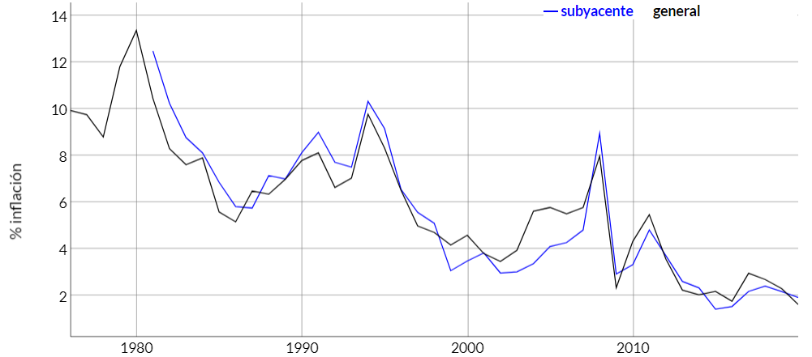

## Evolución mundial desde el 2000

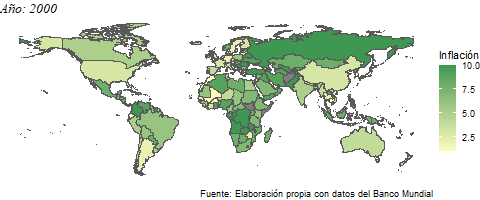

## Outliers

[figure not shown]

## INFLACIÓN ACTUAL

### ¿Qué está sucediendo en Europa?

## Cambio de tendencia

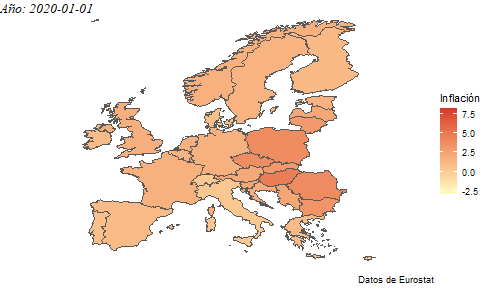

## Diferencias entre general y subyacente

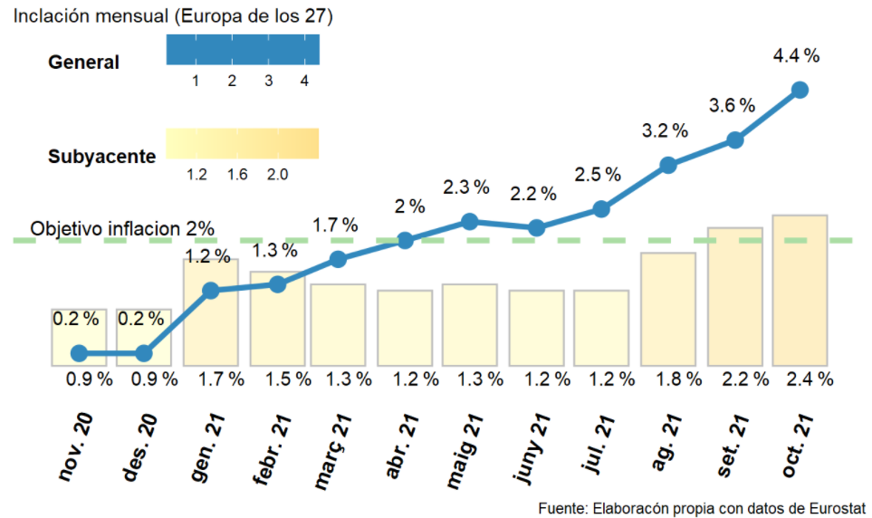

## ¿Qué ha contribuido al aumento de los precios?

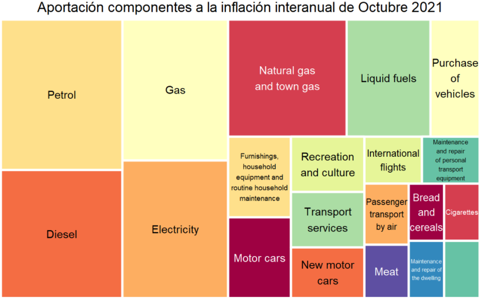

## INFLACIÓN EN ESPAÑA

### ¿Seguimos la tendencia Europea?

## Evolución del IPC en España

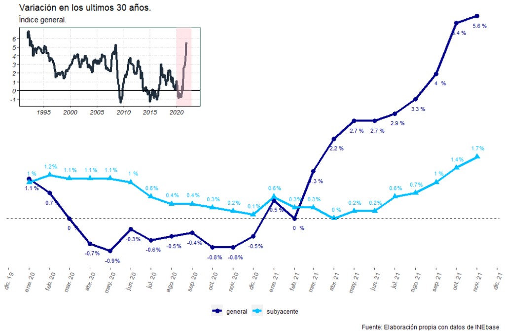

## Comunidades

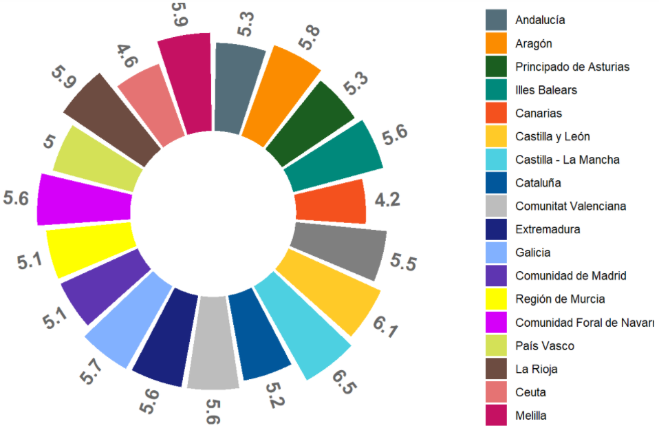

## Provincias

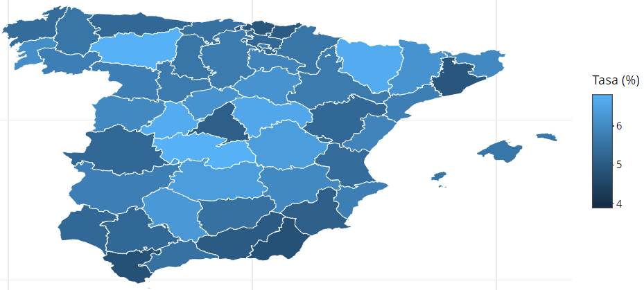

[figure not shown]

## CONSECUENCIAS

### ¿A quién afecta más la subida de precios?

## Propiedades

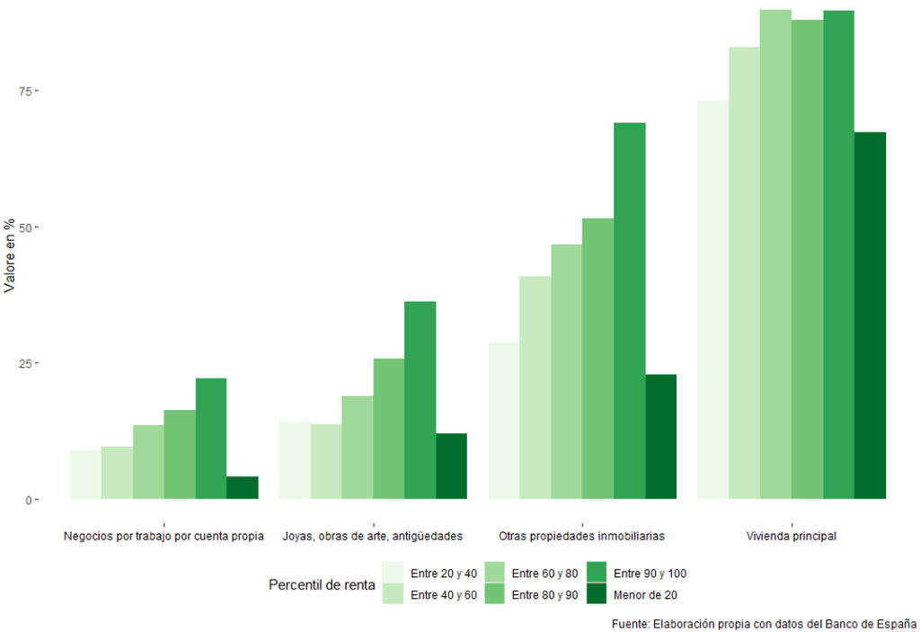

## Activos

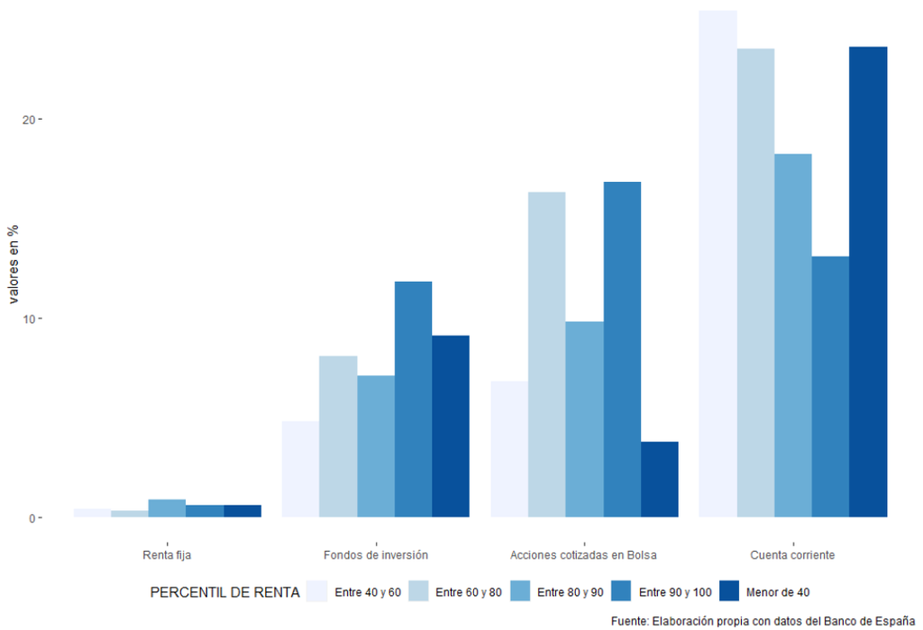

## PREVISIONES

### ¿Actuará el BCE?

## Previsiones de inflación Eurozona

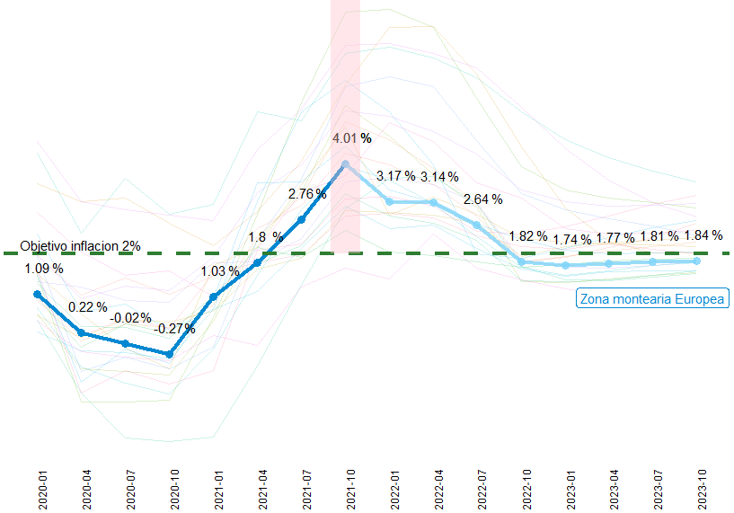

## Previsiones de crecimiento

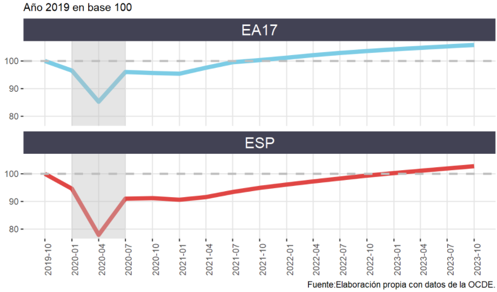

## Deuda/PIB 2020

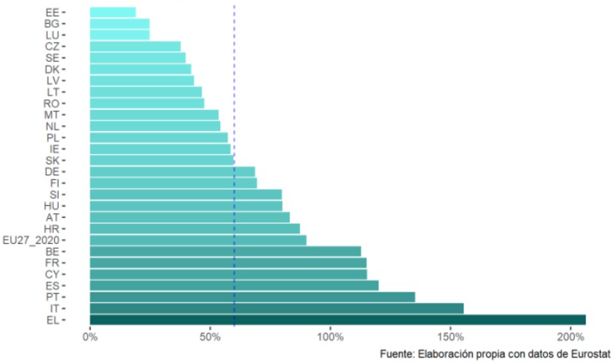

## Bibliografía.

Para la realización de los gráficos y los comentarios pertinentes nos hemos basado en la información que vamos a exponer en los siguientes párrafos.

Para poder realizar los comentarios, nos hemos formado con artículos como los siguientes:

- https://www.eleconomista.es/economia/amp/11501369/Powell-alerta-de-que-tras-Omnicron-la-inflacion-ya-no-es-transitoria
- https://www.caixabankresearch.com/en/publicaciones/notas-breves-actualidad-economica-y-financiera/internacional/aumento-generalizado-y
- https://www.eleconomista.es/flash/#flash_15450

Además, para la elaboración de gráficos que nos parecían útiles para implementar en el trabajo, hemos consultado información sobre como elaborar un [treemap](https://www.r-graph-gallery.com/treemap.html%22), para observar la importancia de los componentes, un [barplot circular](https://www.r-graph-gallery.com/296-add-labels-to-circular-barplot.html), para representar las comunidades autónomas, entre otros.

(Para consultar todas las referencias puede acudir [aquí](https://fran2200.github.io/trabajo_BigData_equipo/))